Prototype · 2026-11-07 · Fable · no app code touched

# My Shop and Plans at 820 and 1440 — the phone unchanged

**The ask (owner, 7 Nov, live My Shop at desktop width):** *"the page doesn't look like a dashboard well thought of"* · *"shop and plan doesn't seem to have a tablet/desktop view"*. On a 1440 screen `/vendor-dashboard/shop` is one phone column (48 rem, `tab:max-w-3xl`) centred with empty space either side; `/vendor-dashboard/subscription` is narrower still (36 rem, `max-w-xl`) and has no pinned row at all.

**What this does:** keeps every row, label, number and action the shipped pages have, and changes only the layout at 820 and 1440 — by dropping both pages into the **two columns the supplier frame already ships** (`SupplierColumns`, `supplier-frame.css` · the list left, the opened item right · 1 : 1 from 701, 5 : 6 from 1100) that Today, Customers › Events and the Hub already use, and that the owner-approved v13 drawing gives Shop › Services. One delta reaches the phone: the black "Finish profile" button, which breaks the button rule at every width.

### Rule 0 — what exists · what is missing · the delta

- **Exists (shipped):** `app/vendor-dashboard/shop/page.tsx` (HeroCard · ShopSegments pinned row · ShopServiceRows · the "Your shop" DatesRows · ServicesDisclosure · Manpower fold · SupplierThumbRow) · `subscription/_components/plan-screen.tsx` + `plan-rows.tsx` + `plan-picker.tsx` · the frame: `layout.tsx` (`boundary="tab"`, `pinnedBar`), `_components/supplier-columns.tsx` (`.sn-cols`), `supplier-open-row.tsx`, `supplier-frame.css`, `pin-door.tsx`, `supplier-thumb-row.tsx` (from 701 the thumb row moves up into the bar's `[data-pin-tools]`).
- **Exists (design):** supplier dashboard **v13, owner "Approved." 29 Oct** — `setnayan-handoff-src/carry-2026-10-29/supplier-dashboard-proto/index.html` + `V13-BUILD-NOTES.md` (S1 shell: "two columns (list · opened item)"; S5 Shop › Services) — its desktop/tablet shots are embedded below. Also `prototypes/desktop_layouts_2026-10-22.html` family 2 (one shell, 48/64-rem columns — the ruling v13 then widened for Today, Events and Hub), `prototypes/vendor_dashboard_redesign_2026-09-22.html` ("Set up your shop · five steps") and `prototypes/vendor_dashboard_rearranged_2026-08-26.html` (where the 46 screens live) — both phone-only drawings; neither draws a width above 430.
- **Missing:** My Shop and Plans never took the v13 two columns — the guard `the-columns-are-the-system.test.ts` still pins Shop › Services to the 48-rem reading column (the 22 Oct ruling), and Plans is not in that guard at all. Plans has no pinned row.
- **Delta drawn here:** both pages in `SupplierColumns` from 701; the pane's default = the shop card (My Shop) / "What Free gives you" (Plans); a pinned row on Plans; the hero CTA on the button rule. Nothing else moves; the phone keeps its rows in the shipped order.

### House rules used (cited where each change says so)

- **Always maximize the screen** — owner 29 Oct ("remember to always maximize the screen use"): on tablet/desktop use the width (side panel, columns) instead of a centred phone strip; no crushed columns.
- **The pinned row is the template** — owner 27 Oct: one pinned row per page: selector · counts · one action · ⚙ (DECISION_LOG "THE PINNED ROW IS THE APP-WIDE TEMPLATE"; v13 "EVERY SUPPLIER-DASHBOARD PAGE: THE TOP ROWS COMPRESS INTO ONE PINNED ROW").
- **BUTTON_RULE_2026-10-07** (`BUTTON_RULE_2026-10-07_fable.md`): every control is a 44-px pill, icon + word; one colour per meaning — terracotta = forward/save, green = Done/money, grey = Cancel, red = Remove.
- **Frames only on what you press; dividers between topics** — owner 2026-10-11. **Details go inside the ⓘ** — owner 23 Oct. **Rows: tap opens, swipe left removes** — owner 4 Nov. **Any set of choices is a dropdown** — DECISION_LOG 2026-09-28.
- **MY SHOP WALK — SEVEN OWNER FINDINGS** — DECISION_LOG 2026-09-23 (⓸ "Why add save buttons?", ⓺ one fact two writers, "there are a lot of inconsistencies on this shop page") — the inconsistency list at the end continues that walk.
- **Prototypes use the app's real tokens** — owner 4 Nov: this file's `:root` is copied from `apps/web/app/globals.css` (light + `html.dark`), font Hanken Grotesk.

## 1 · Baselines — what ships, and what was already approved

Captured today from the dev labs on a dummy env (no sign-in, no database) at 390 / 820 / 1440 with the real One Shell (`&shell=1`). **No lab renders My Shop itself** (`/vendor-dashboard/shop` needs a signed-in shop; `shop-layout-lab`, `shop-plan-lab`, `shop-page-lab` and `shop-preview-lab` all draw the *public* shop page `/v/[slug]`) — so the shipped My Shop is **drawn from `shop/page.tsx`** below, labelled as such, and the owner's own description is the check.

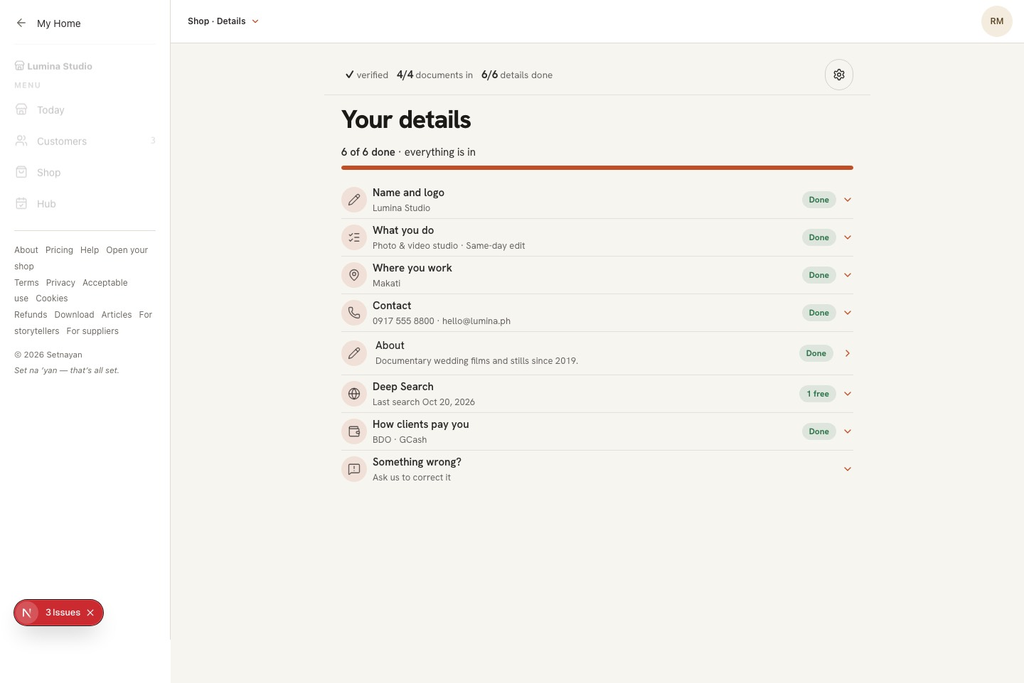

real · lab **The frame at 1440 — Shop › Details (`/dev/supplier-lab?s=details&shell=1`)**240-px rail · the bar with "Shop · Details ▾" · the page's pinned figures + ⚙ · then the 48-rem column with space either side. My Shop sits in this same column.

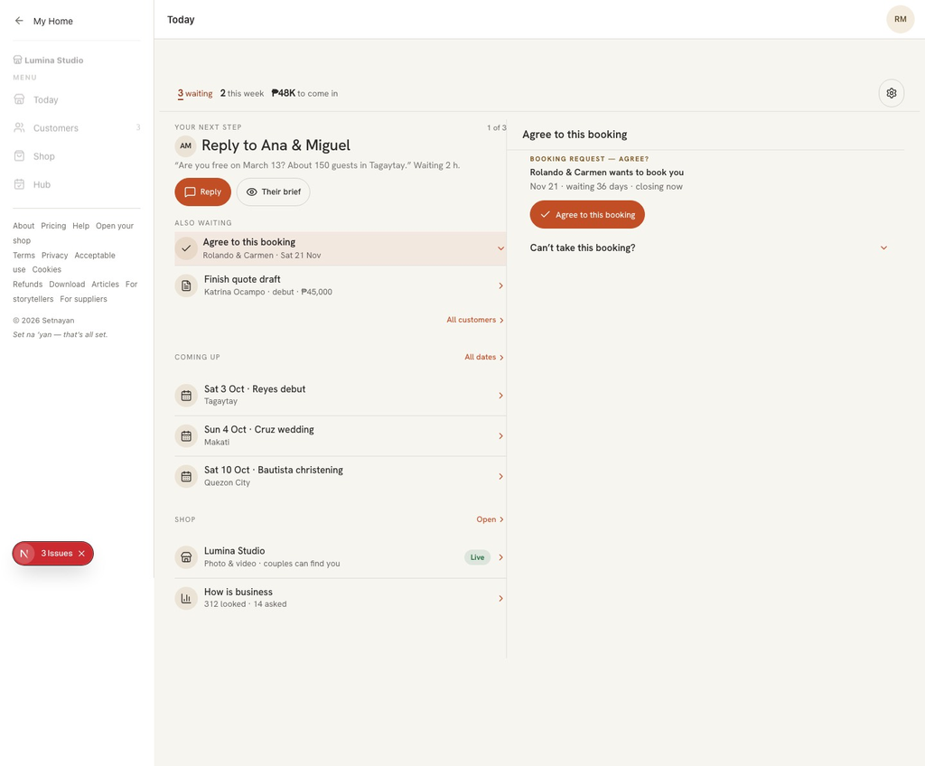

real · lab **The pattern that already ships — Today at 1440 (`?s=today&shell=1`)**Rows left, the opened row right (`SupplierColumns`, `SupplierOpenScope`). This is what My Shop and Plans are moved onto.

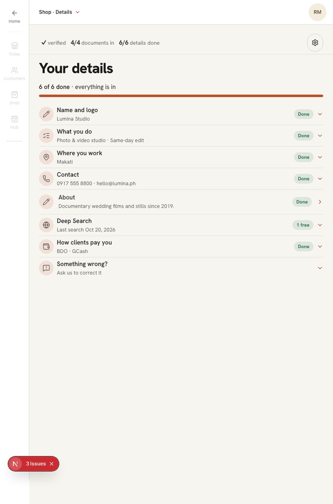

real · lab **The frame at 820**The 72-px icon strip, the bar, the pinned figures — and one centred column again.

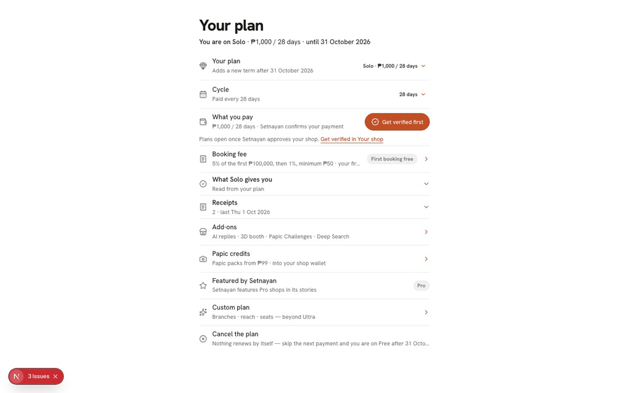

real · lab **Plans at 1440 (`/dev/supplier-plan-lab?s=plan&unverified=1`)**A 36-rem column (`max-w-xl`), no pinned row, the h1 "Your plan". The lab draws it without the rail (the rail needs a sign-in) — the same measure the live page uses.

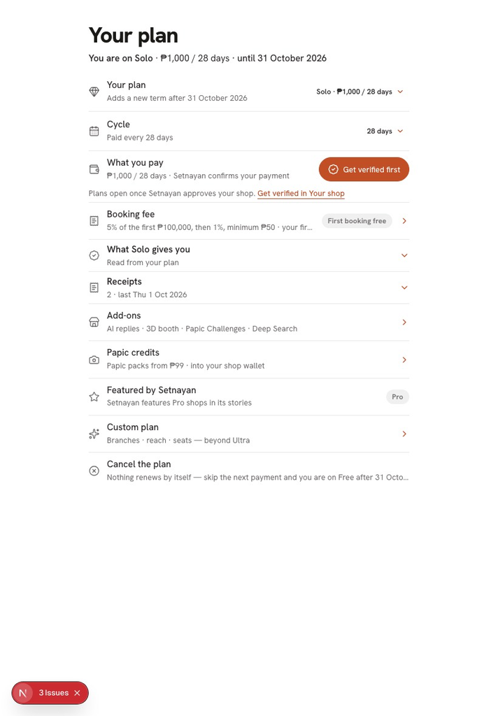

real · lab **Plans at 820**

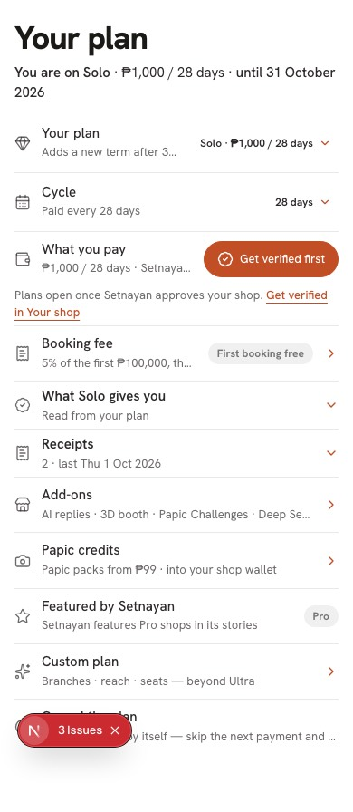

real · lab **Plans at 390 — unchanged in this proposal**

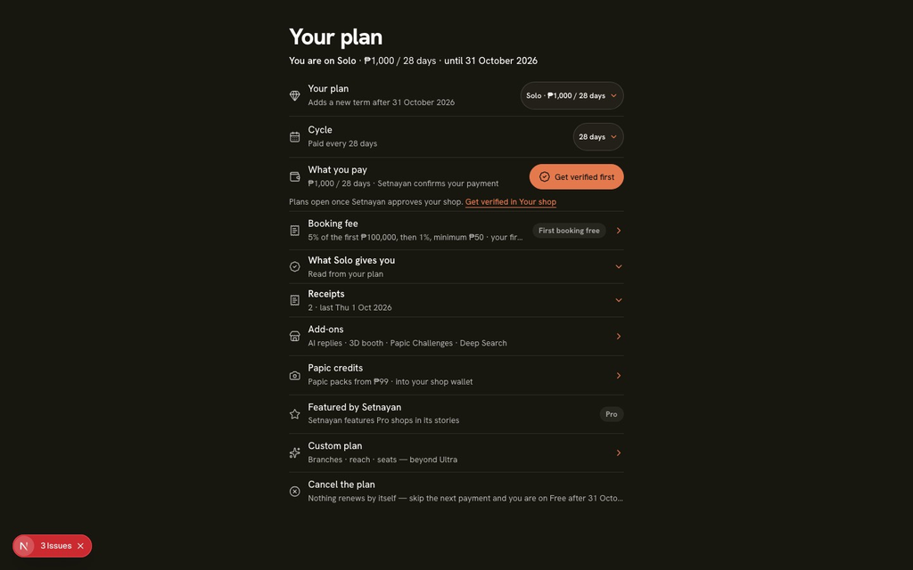

real · lab **Plans at 1440 with `html.dark`** (the app is light-locked; the dark block is inert but coherent).

[figure not shown]

real · lab **The phone frame at 390**The "Shop · Details ▾" pill in the bar, the figures row, one column — the contract that does not move.

### The approved design the page never got — supplier dashboard v13 (owner "Approved.", 29 Oct)

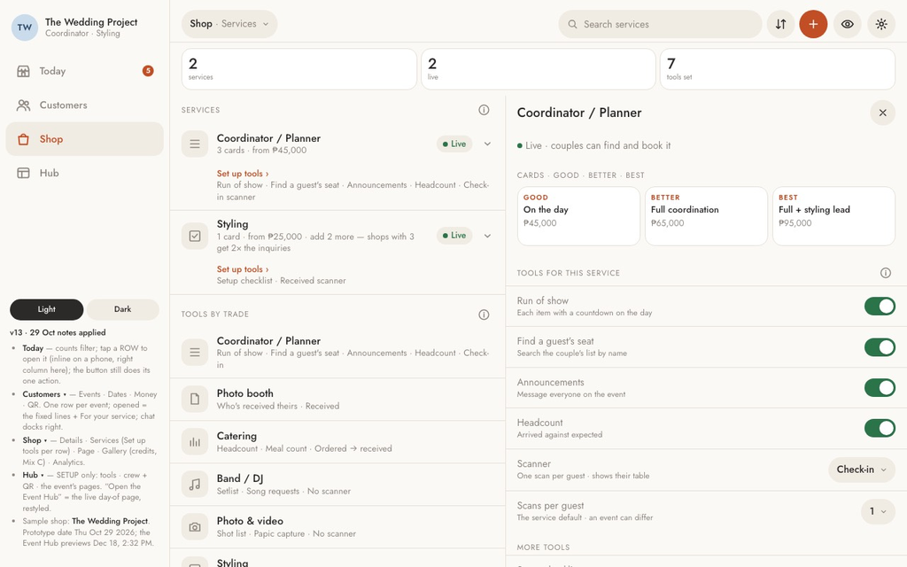

approved · v13 **Shop › Services · desktop**Figures across the top, services list left, the opened service right. Note: v13 keeps no shop card on Services — its Details screen carries "Live · ✓ verified · 72% profile" as figures instead.

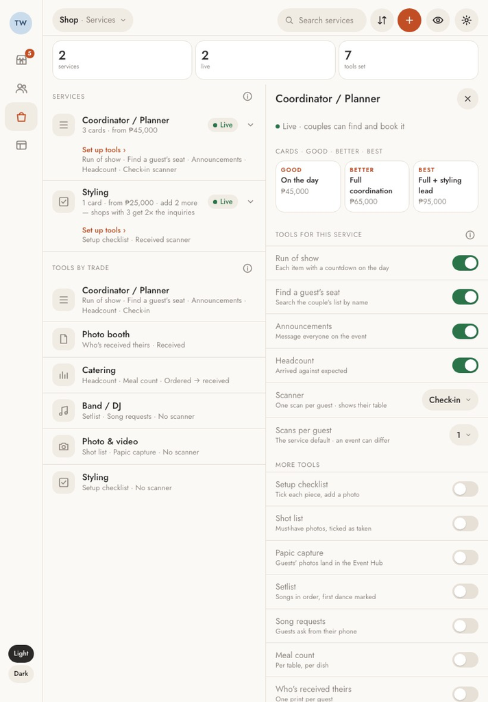

approved · v13 **Shop › Services · tablet (820)**Same two columns, 1 : 1, the 72-px strip.

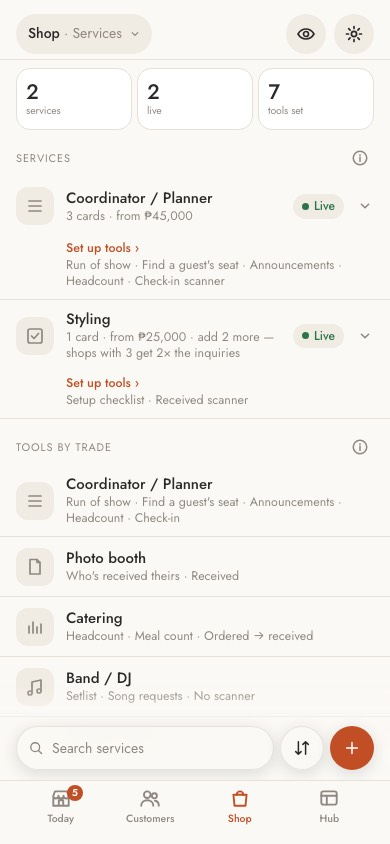

approved · v13 **Shop › Services · phone**One column, the thumb row — what shipped on the phone follows this.

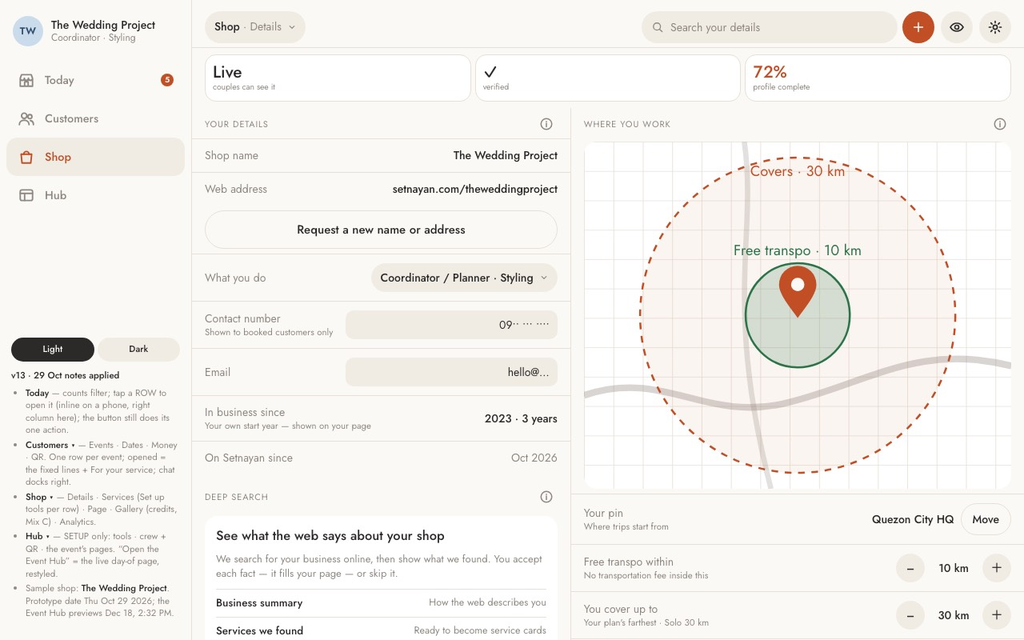

approved · v13 **Shop › Details · desktop**Details left, the map right — the "pane is never empty" rule: each page hands a default.

## 2 · My Shop — proposal at 1440 and 820

The page drops into `SupplierColumns name="shop"` from 701. **Left** = every row the phone has, in the phone's order: the Services rows, then the "Your shop" door rows, then the folds. **Right** = the pane, never empty: its default is **the shop card** (the hero: logo · name · verification pill · plan · service · city · address · profile ring · the one next step) — the thing every row below is about. Tap a row and it opens beside itself (`SupplierOpenRow`, the soft accent wash on the current row); the shop card returns when nothing is open.

1. **1***Pinned row stays the pinned row.* "Shop · Services ▾" is the bar's menu from 701 (as shipped); the figures "0 services · 0 live · 0 tools ready" and the ⚙ keep the page's own row. The thumb row's "＋ Add a service" rides up into the bar's tools box, as `supplier-thumb-row.tsx` already does from 701.the pinned row is the template · selector · counts · action · ⚙
2. **2***Two columns, the full width.* List left (5 fr), pane right (6 fr), the pane sticky under the pin line and scrolling on its own — the shipped `.sn-cols`. No more 48-rem strip with margins either side.always maximize the screen · v13 S1 "two columns (list · opened item)"
3. **3***The shop card is the pane's default.* Same content as the shipped hero, one change: the black "Finish profile →" becomes the terracotta main verb with its icon, 44-px pill; "Copy link" is an outlined pill (a control, not a text link). The ring, the pill "Get verified · 0 of 2", the address line and its note are untouched.BUTTON_RULE_2026-10-07 · terracotta = forward · every control is a pill, icon + word
4. **4***Rows keep their shape.* Title + one line, badge, the terracotta ›; hairlines between rows, no boxes. "Your shop" keeps its head and question as a divider between the Services topic and the shop topic.frames only on what you press · details inside the ⓘ
5. **5***"Your services" (the full manager) and Manpower stay as folds at the foot of the list*, exactly as shipped (`ServicesDisclosure defaultOpen`, `FeatureAccordion measure="reading"`). At 1440 their open bodies draw in the pane instead of pushing the list down — the same "open beside itself" every other fold on the frame uses.

1. **6***A door row opens in the pane* — here Your documents (`/vendor-dashboard/profile#docs`, the shipped `VerifySection`: "Your documents" + "Confirm your contacts", the papers from `lib/vendor-verification.ts`). The row wears the accent wash while open; ✕ returns the shop card. On the phone the same tap navigates, as today.rows: tap opens · v13 "≥700 px = open in the right column"
2. **7***Three doors to one room, now visibly beside each other:* the "Get verified · 0 of 2" pill, the Your documents row and the Shop ⚙ › "Verification and documents" fold all open this. Kept as shipped; listed under inconsistencies.

1. **8***Service rows as shipped* (`shop-service-rows.tsx`): name, "N cards · from ₱", Live / Ready, "Tools on every event · …". The figures count them: 3 services · 1 live · 4 tools ready (`servicesFigures`). The tapped service opens in the pane with the v13-approved body: Live line · cards · tools switches · scanner ▾ — the shipped manager's content, not a second editor.
2. **9***Verified shop:* the chip reads "Verified", Your page says "Couples can see it", Your documents "Verified", and the hero's one action is "View as couple" — green is not used here because it is not Done/money; it stays the main (terracotta) verb, with the arrow icon it already has.BUTTON_RULE · one colour per meaning
3. **10***"Band / DJ", not "Band Dj".* The subline reads the taxonomy's own label (`resolveCoverageLabels().leafLabel`, the same source the rows use) instead of `titleCase(profile.services[0])`. One word per concept — see inconsistencies.the taxonomy has one source · owner 26 Oct

1. **11***Tablet = the same two columns at 1 : 1* (`supplier-frame.css` 701–1099). Row lines truncate with an ellipsis rather than wrapping; the hero stacks the ring under the name at this width so the name line never crushes. The strip rail is the shipped 72-px strip.always maximize the screen · no crushed columns

## 3 · Plans — proposal at 1440 and 820

Plans is one screen in two seats (`PlanScreen`: the page, and the Shop ⚙ › "Plan and billing" fold). The page's own column is `max-w-xl` (36 rem) — narrower than every other supplier page — and it has no pinned row. Proposal: the same two columns; **left** = the answer line + every row as shipped (`plan-rows.tsx`, `plan-picker.tsx`); **right** = the first fold opened by default, "What Free gives you" (read from your plan), and whichever fold or row is tapped after. The Add-ons cards, today a second page below the rows, become what the "Add-ons ›" row opens in the pane.

1. **12***A pinned row, like every other supplier page:* the bar's menu names the page ("Shop · Plan", from the Shop ⚙'s own fold title "Plan and billing"); the row carries the answer line as its figure doors — **Free** plan · **₱0** to pay · **0** receipts — and the ⚙. The h1 "Your plan" folds into it on scroll. ⚠ Open call: `PinFigure` wants a number + a word; "Free · plan" is a word in a number's place — the honest alternative is the answer line itself as the row's text.the pinned row is the template
2. **13***The picker rows are unchanged* — Your plan ▾ · (Cycle ▾ only on a paid pick) · What you pay with the one terracotta Pay, or "Get verified first" for an unverified shop (`plan-picker.tsx`). Any set of choices is the one PickMenu.any set of choices is a dropdown
3. **14***The pane's default is the first fold*, "What Free gives you" — its eight lines are the ones `planGivesLines('free')` prints today (captured from the lab). Receipts, Add-ons, Papic credits, Custom plan each open here when tapped; nothing is added, nothing is dropped.v13 · the pane is never empty · rows: tap opens
4. **15***The column widens from 36 rem to the frame.* Plans joins `the-columns-are-the-system.test.ts` with the other two-column pages (`tab:max-w-none`).always maximize the screen

1. **16***Add-ons open beside the row* — the shipped cards (`AiAddonCard`, `BoothAddonCard`, `PapicChallengeCard`, the Deep Search door) unchanged in words; for a Free, unverified shop each says what it says today ("Get your shop verified to unlock …"). On the phone the row still jumps to `#add-ons` below.

## 4 · The phone (390) — unchanged, one delta

Below 701 nothing moves: the order, the rows, the pinned row with "Shop · Services ▾", the thumb row's "＋ Add a service", the bottom tabs. The one change that reaches the phone is the hero's button, because a rule that holds on the desk and not on the phone is two rules.

1. **17***"Finish profile" on the button rule at 390 too* — terracotta pill, icon + word, 44 px (today: a black 12-px-radius block, `style={{ background: 'var(--m-ink)' }}` in `HeroCard`). Same for "View as couple" and "Get verified" / "Manage shop", which share the style.BUTTON_RULE_2026-10-07
2. **18***Plans on the phone gains the pinned row* (the answer line folds into it on scroll) and nothing else; the h1 stays.

## 5 · Inconsistencies found (continuing the 2026-09-23 My Shop walk)

[output not shown]